# Mummichog Report: data_pos_group1_before_blank_subtraction

mummichog version: 2.2.0-20200207, using metabolic model MFN_1.10.4.

## User input data

User supplied 2580 features as reference list.We are using 517 features (p < 0.050000) as significant list. The feature level data are shown in the Manhattan plots below.

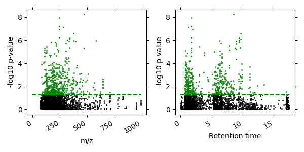

## Top pathways

| Pathways | overlap_size | pathway_size | p-value | overlap_EmpiricalCompounds |
| --- | --- | --- | --- | --- |
| Linoleate metabolism | 6 | 10 | 0.01647 | E483,E66,E397,E569,E205,E647 |
| Phosphatidylinositol phosphate metabolism | 4 | 6 | 0.03109 | E583,E17,E27,E362 |
| Pentose and Glucuronate Interconversions | 3 | 4 | 0.0363 | E583,E537,E641 |
| Glyoxylate and Dicarboxylate Metabolism | 2 | 2 | 0.03815 | E537,E641 |
| Prostaglandin formation from arachidonate | 7 | 15 | 0.06168 | E462,E406,E493,E394,E126,E647,E294 |

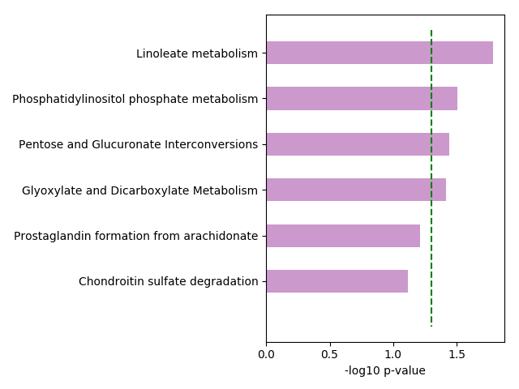

## Top modules

module_1, p=0.00706, 10 metabolites

D-Ribose, Xanthine, Guanosine, Adenine, Uridine, 5-Methylthioadenosine, Deoxyadenosine, Hypoxanthine, Cytidine, Deoxycytidine

module_2, p=0.03451, 5 metabolites

Cytidine, Guanosine, Deoxyadenosine, Deoxycytidine, Uridine

## EmpiricalCompounds favored by above analyses

An EmpiricalCompound is a computational unit for a tentative metabolite. It can group multiple ions, and be any of the isobaric/isomeric species. This table contains EmpiricalCompounds prioritized by pathway/module analysis.

| EmpiricalCompound | Input m/z | Retention time | ion | mz_diff | Statistic | Significant |
| --- | --- | --- | --- | --- | --- | --- |
| E451 | Best guess: C00299, Uridine |  | C00299 |  |  |  |
|  | 245.076904374 | 1.14527017544 | M+H[1+] | 0.0001 | 2.76 | yes |
| E17 | Best guess: C00208, Maltose |  | C01083, C01235, C00252, C00897, C00089, C00243, C00185, C05400, C05402, C06373, C00208 |  |  |  |
|  | 365.104993534 | 0.860335416667 | M+Na[1+] | -0.0005 | 3.96 | yes |
| E495 | Best guess: C00299, Uridine |  | C00299 |  |  |  |
|  | 245.078298049 | 11.1672098485 | M+H[1+] | 0.0015 | 4.98 | yes |
| E124 | Best guess: C00559, Deoxyadenosine |  | C00559, C05198 |  |  |  |
|  | 274.091902934 | 1.0224625 | M+Na[1+] | 0.0008 | 2.39 | yes |
|  | 274.091833475 | 0.906294791667 | M+Na[1+] | 0.0008 | 1.87 | no |
| E325 | Best guess: C00385, Xanthine |  | C00385 |  |  |  |
|  | 153.040974334 | 5.58471018519 | M+H[1+] | 0.0003 | 3.8 | yes |
| E583 | Best guess: C00618, 3-Dehydro-L-gulonate |  | C06472, C00191, C00618 |  |  |  |
|  | 195.05178247 | 1.015534375 | M+H[1+] | 0.0018 | 3.21 | yes |
| E397 | Best guess: CE5527, |  | C14765, CE5526, CE5527 |  |  |  |
|  | 317.211115096 | 9.82032843137 | M+Na[1+] | 0.0024 | 3.84 | yes |
|  | 317.211203506 | 9.68639895833 | M+Na[1+] | 0.0024 | 3.95 | yes |
| E377 | Best guess: C00387, Guanosine |  | C00387 |  |  |  |
|  | 285.100968293 | 5.723125 | M(C13)+H[1+] | -0.0014 | 2.57 | yes |
|  | 284.099195606 | 5.419785 | M+H[1+] | 0.0002 | 0.61 | no |
| E130 | Best guess: C00170, 5-Methylthioadenosine |  | C00170 |  |  |  |
|  | 298.097213616 | 6.19258541667 | M+H[1+] | 0.0003 | 5.18 | yes |
| E362 | Best guess: C03785, D-Tagatose 1,6-bisphosphate |  | C01231, C05378, C03693, C00665, C01220, C00354, C04063, C04062, C03785 |  |  |  |
|  | 408.991688101 | 1.249609375 | M+HCOONa[1+] | 0.001 | 3.41 | yes |
|  | 362.98519455 | 0.918451754386 | M+Na[1+] | -0.0001 | 0.38 | no |
| E378 | Best guess: C00475, Cytidine |  | C05711, C00475 |  |  |  |
|  | 245.096393475 | 1.91156666667 | M(C13)+H[1+] | 0.0002 | 9.81 | yes |
|  | 244.093353875 | 1.68102833333 | M+H[1+] | 0.0006 | 10.32 | yes |
| E641 | Best guess: C00121, D-Ribose |  | C00312, C00310, C00508, C00259, C00181, C00309, C00121 |  |  |  |
|  | 173.042361688 | 0.913500793651 | M+Na[1+] | 0.0003 | 4.35 | yes |
| E66 | Best guess: C04717, (9Z,11E)-(13S)-13-Hydroperoxyoctadeca-9,11-dienoic acid |  | C14827, C04717 |  |  |  |
|  | 335.221553628 | 9.82158333333 | M+Na[1+] | 0.0022 | 4.68 | yes |
| E647 | Best guess: C02670, D-glucurono-6,3-lactone |  | glac, C00072, C02670 |  |  |  |
|  | 177.039696334 | 1.24831315789 | M+H[1+] | 0.0003 | 2.39 | yes |
|  | 199.021541595 | 1.2479 | M+Na[1+] | 0.0002 | 2.72 | yes |
| E522 | Best guess: C00262, Hypoxanthine |  | C00262 |  |  |  |
|  | 159.028823816 | 1.25061666667 | M+Na[1+] | 0.001 | 2.42 | yes |
| E317 | Best guess: C00881, Deoxycytidine |  | C00881 |  |  |  |
|  | 228.098237271 | 2.12843611111 | M+H[1+] | 0.0004 | 2.19 | yes |
|  | 250.080080668 | 2.13657777778 | M+Na[1+] | 0.0002 | 1.66 | no |
|  | 250.08001983 | 2.22256145833 | M+Na[1+] | 0.0001 | 0.36 | no |
|  | 228.098156641 | 2.21732916667 | M+H[1+] | 0.0003 | 0.34 | no |
| E205 | Best guess: CE5527, |  | C14765, CE5526, CE5527 |  |  |  |
|  | 317.211128424 | 8.90828229167 | M+Na[1+] | 0.0024 | 5.81 | yes |
| E537 | Best guess: C00121, D-Ribose |  | C00312, C00310, C00508, C00259, C00181, C00309, C00121 |  |  |  |
|  | 173.042610519 | 1.30252105263 | M+Na[1+] | 0.0005 | 2.32 | yes |
| E569 | Best guess: C04717, (9Z,11E)-(13S)-13-Hydroperoxyoctadeca-9,11-dienoic acid |  | C14827, C04717 |  |  |  |
|  | 335.221562696 | 9.32500833333 | M+Na[1+] | 0.0022 | 3.74 | yes |
|  | 335.221566956 | 8.90692395833 | M+Na[1+] | 0.0022 | 8.13 | yes |
| E27 | Best guess: CE3075, sorbitol 3-phosphate |  | C00092, C02965, C05345, C00085, C00103, C02976, C01171, C01172, C01177, C03735, C00636, C03862, C04006, C01097, C01094, C00668, C03546, C00446, C00275, CE3075 |  |  |  |
|  | 283.019097905 | 1.04759479167 | M+Na[1+] | 0.0001 | 0.92 | no |
|  | 131.022740926 | 1.25828070175 | M+2H[2+] | 0.0006 | 2.16 | yes |
|  | 283.018976595 | 0.726420588235 | M+Na[1+] | -0.0 | 3.04 | yes |
|  | 283.019054942 | 1.126203125 | M+Na[1+] | 0.0001 | 1.55 | no |
|  | 283.019034386 | 0.824247916667 | M+Na[1+] | 0.0 | 2.15 | yes |
| E601 | Best guess: C00147, Adenine |  | C00147 |  |  |  |
|  | 158.044877355 | 1.54258863636 | M+Na[1+] | 0.0011 | 1.98 | no |
|  | 136.062072199 | 1.56525378788 | M+H[1+] | 0.0003 | 3.82 | yes |
| E483 | Best guess: C14826, 12(13)-EpOME |  | C14762, C14825, C14826 |  |  |  |
|  | 319.226647108 | 9.421440625 | M+Na[1+] | 0.0023 | 8.26 | yes |
|  | 319.226679365 | 9.90060729167 | M+Na[1+] | 0.0023 | 4.19 | yes |
|  | 319.226560036 | 9.66317708333 | M+Na[1+] | 0.0022 | 3.52 | yes |

## More data

Full data tables from pathway analysis, module analysis and activity network are stored in the 'tables/' directory. The tsv files can be imported into a spreadsheet program, e.g. MS Excel. Under the 'figures/network_modules/' directory are files intended for Cytoscape (cytoscape.org) visualization. Please refer to Cytoscape's guides for details. Details of this run are recorded in file mummichog.log.txt.